# Risk Factor Analysis

## Outcome Variable

**Outcome Variable:** wast_rec90d

## Predictor Variables

**Intervention Variable:** single

**Adjustment Set:**

- arm
- W_mage
- meducyrs
- feducyrs
- W_mhtcm
- W_mwtkg
- W_mbmi
- delta_W_mage
- delta_meducyrs
- delta_feducyrs
- delta_W_mhtcm
- delta_W_mwtkg
- delta_W_mbmi

## Stratifying Variables

The analysis was stratified on these variable(s):

- agecat
- studyid
- country

## Data Summary

| agecat | studyid | country | single | wast_rec90d | n_cell | n |
| --- | --- | --- | --- | --- | --- | --- |
| 0-24 months | ki0047075b-MAL-ED | BANGLADESH | 0 | 0 | 45 | 124 |
| 0-24 months | ki0047075b-MAL-ED | BANGLADESH | 0 | 1 | 79 | 124 |
| 0-24 months | ki0047075b-MAL-ED | BANGLADESH | 1 | 0 | 0 | 124 |
| 0-24 months | ki0047075b-MAL-ED | BANGLADESH | 1 | 1 | 0 | 124 |
| 0-24 months | ki0047075b-MAL-ED | BRAZIL | 0 | 0 | 5 | 23 |
| 0-24 months | ki0047075b-MAL-ED | BRAZIL | 0 | 1 | 13 | 23 |
| 0-24 months | ki0047075b-MAL-ED | BRAZIL | 1 | 0 | 1 | 23 |
| 0-24 months | ki0047075b-MAL-ED | BRAZIL | 1 | 1 | 4 | 23 |
| 0-24 months | ki0047075b-MAL-ED | INDIA | 0 | 0 | 71 | 177 |
| 0-24 months | ki0047075b-MAL-ED | INDIA | 0 | 1 | 106 | 177 |
| 0-24 months | ki0047075b-MAL-ED | INDIA | 1 | 0 | 0 | 177 |
| 0-24 months | ki0047075b-MAL-ED | INDIA | 1 | 1 | 0 | 177 |
| 0-24 months | ki0047075b-MAL-ED | NEPAL | 0 | 0 | 20 | 93 |
| 0-24 months | ki0047075b-MAL-ED | NEPAL | 0 | 1 | 73 | 93 |
| 0-24 months | ki0047075b-MAL-ED | NEPAL | 1 | 0 | 0 | 93 |
| 0-24 months | ki0047075b-MAL-ED | NEPAL | 1 | 1 | 0 | 93 |
| 0-24 months | ki0047075b-MAL-ED | PERU | 0 | 0 | 4 | 34 |
| 0-24 months | ki0047075b-MAL-ED | PERU | 0 | 1 | 22 | 34 |
| 0-24 months | ki0047075b-MAL-ED | PERU | 1 | 0 | 2 | 34 |
| 0-24 months | ki0047075b-MAL-ED | PERU | 1 | 1 | 6 | 34 |
| 0-24 months | ki0047075b-MAL-ED | SOUTH AFRICA | 0 | 0 | 8 | 83 |
| 0-24 months | ki0047075b-MAL-ED | SOUTH AFRICA | 0 | 1 | 34 | 83 |
| 0-24 months | ki0047075b-MAL-ED | SOUTH AFRICA | 1 | 0 | 9 | 83 |
| 0-24 months | ki0047075b-MAL-ED | SOUTH AFRICA | 1 | 1 | 32 | 83 |
| 0-24 months | ki0047075b-MAL-ED | TANZANIA, UNITED REPUBLIC OF | 0 | 0 | 7 | 45 |
| 0-24 months | ki0047075b-MAL-ED | TANZANIA, UNITED REPUBLIC OF | 0 | 1 | 33 | 45 |
| 0-24 months | ki0047075b-MAL-ED | TANZANIA, UNITED REPUBLIC OF | 1 | 0 | 1 | 45 |
| 0-24 months | ki0047075b-MAL-ED | TANZANIA, UNITED REPUBLIC OF | 1 | 1 | 4 | 45 |
| 0-24 months | ki1066203-TanzaniaChild2 | TANZANIA, UNITED REPUBLIC OF | 0 | 0 | 236 | 710 |
| 0-24 months | ki1066203-TanzaniaChild2 | TANZANIA, UNITED REPUBLIC OF | 0 | 1 | 409 | 710 |

[output cut: 138 more lines]

The following strata were considered:

- agecat: 0-24 months, studyid: ki0047075b-MAL-ED, country: BANGLADESH
- agecat: 0-24 months, studyid: ki0047075b-MAL-ED, country: BRAZIL
- agecat: 0-24 months, studyid: ki0047075b-MAL-ED, country: INDIA
- agecat: 0-24 months, studyid: ki0047075b-MAL-ED, country: NEPAL
- agecat: 0-24 months, studyid: ki0047075b-MAL-ED, country: PERU
- agecat: 0-24 months, studyid: ki0047075b-MAL-ED, country: SOUTH AFRICA
- agecat: 0-24 months, studyid: ki0047075b-MAL-ED, country: TANZANIA, UNITED REPUBLIC OF
- agecat: 0-24 months, studyid: ki1066203-TanzaniaChild2, country: TANZANIA, UNITED REPUBLIC OF
- agecat: 0-24 months, studyid: ki1112895-Guatemala BSC, country: GUATEMALA
- agecat: 0-24 months, studyid: ki1119695-PROBIT, country: BELARUS
- agecat: 0-24 months, studyid: ki1126311-ZVITAMBO, country: ZIMBABWE
- agecat: 0-24 months, studyid: ki1135781-COHORTS, country: GUATEMALA
- agecat: 0-24 months, studyid: ki1135781-COHORTS, country: INDIA
- agecat: 0-24 months, studyid: ki1135781-COHORTS, country: PHILIPPINES
- agecat: 0-6 months, studyid: ki0047075b-MAL-ED, country: BANGLADESH
- agecat: 0-6 months, studyid: ki0047075b-MAL-ED, country: BRAZIL
- agecat: 0-6 months, studyid: ki0047075b-MAL-ED, country: INDIA
- agecat: 0-6 months, studyid: ki0047075b-MAL-ED, country: NEPAL
- agecat: 0-6 months, studyid: ki0047075b-MAL-ED, country: PERU
- agecat: 0-6 months, studyid: ki0047075b-MAL-ED, country: SOUTH AFRICA
- agecat: 0-6 months, studyid: ki0047075b-MAL-ED, country: TANZANIA, UNITED REPUBLIC OF
- agecat: 0-6 months, studyid: ki1066203-TanzaniaChild2, country: TANZANIA, UNITED REPUBLIC OF
- agecat: 0-6 months, studyid: ki1112895-Guatemala BSC, country: GUATEMALA
- agecat: 0-6 months, studyid: ki1119695-PROBIT, country: BELARUS
- agecat: 0-6 months, studyid: ki1126311-ZVITAMBO, country: ZIMBABWE
- agecat: 0-6 months, studyid: ki1135781-COHORTS, country: GUATEMALA
- agecat: 0-6 months, studyid: ki1135781-COHORTS, country: INDIA
- agecat: 0-6 months, studyid: ki1135781-COHORTS, country: PHILIPPINES
- agecat: 6-24 months, studyid: ki0047075b-MAL-ED, country: BANGLADESH
- agecat: 6-24 months, studyid: ki0047075b-MAL-ED, country: BRAZIL
- agecat: 6-24 months, studyid: ki0047075b-MAL-ED, country: INDIA
- agecat: 6-24 months, studyid: ki0047075b-MAL-ED, country: NEPAL
- agecat: 6-24 months, studyid: ki0047075b-MAL-ED, country: PERU
- agecat: 6-24 months, studyid: ki0047075b-MAL-ED, country: SOUTH AFRICA
- agecat: 6-24 months, studyid: ki0047075b-MAL-ED, country: TANZANIA, UNITED REPUBLIC OF
- agecat: 6-24 months, studyid: ki1066203-TanzaniaChild2, country: TANZANIA, UNITED REPUBLIC OF
- agecat: 6-24 months, studyid: ki1112895-Guatemala BSC, country: GUATEMALA
- agecat: 6-24 months, studyid: ki1119695-PROBIT, country: BELARUS
- agecat: 6-24 months, studyid: ki1126311-ZVITAMBO, country: ZIMBABWE
- agecat: 6-24 months, studyid: ki1135781-COHORTS, country: GUATEMALA
- agecat: 6-24 months, studyid: ki1135781-COHORTS, country: INDIA
- agecat: 6-24 months, studyid: ki1135781-COHORTS, country: PHILIPPINES

### Dropped Strata

Some strata were dropped due to rare outcomes:

- agecat: 0-24 months, studyid: ki0047075b-MAL-ED, country: BANGLADESH
- agecat: 0-24 months, studyid: ki0047075b-MAL-ED, country: BRAZIL
- agecat: 0-24 months, studyid: ki0047075b-MAL-ED, country: INDIA
- agecat: 0-24 months, studyid: ki0047075b-MAL-ED, country: NEPAL
- agecat: 0-24 months, studyid: ki0047075b-MAL-ED, country: PERU
- agecat: 0-24 months, studyid: ki0047075b-MAL-ED, country: TANZANIA, UNITED REPUBLIC OF
- agecat: 0-24 months, studyid: ki1112895-Guatemala BSC, country: GUATEMALA
- agecat: 0-24 months, studyid: ki1135781-COHORTS, country: INDIA
- agecat: 0-6 months, studyid: ki0047075b-MAL-ED, country: BANGLADESH
- agecat: 0-6 months, studyid: ki0047075b-MAL-ED, country: BRAZIL
- agecat: 0-6 months, studyid: ki0047075b-MAL-ED, country: INDIA
- agecat: 0-6 months, studyid: ki0047075b-MAL-ED, country: NEPAL
- agecat: 0-6 months, studyid: ki0047075b-MAL-ED, country: PERU
- agecat: 0-6 months, studyid: ki0047075b-MAL-ED, country: SOUTH AFRICA
- agecat: 0-6 months, studyid: ki0047075b-MAL-ED, country: TANZANIA, UNITED REPUBLIC OF
- agecat: 0-6 months, studyid: ki1112895-Guatemala BSC, country: GUATEMALA
- agecat: 0-6 months, studyid: ki1135781-COHORTS, country: GUATEMALA
- agecat: 0-6 months, studyid: ki1135781-COHORTS, country: INDIA
- agecat: 6-24 months, studyid: ki0047075b-MAL-ED, country: BANGLADESH
- agecat: 6-24 months, studyid: ki0047075b-MAL-ED, country: BRAZIL
- agecat: 6-24 months, studyid: ki0047075b-MAL-ED, country: INDIA
- agecat: 6-24 months, studyid: ki0047075b-MAL-ED, country: NEPAL
- agecat: 6-24 months, studyid: ki0047075b-MAL-ED, country: PERU
- agecat: 6-24 months, studyid: ki0047075b-MAL-ED, country: SOUTH AFRICA
- agecat: 6-24 months, studyid: ki0047075b-MAL-ED, country: TANZANIA, UNITED REPUBLIC OF
- agecat: 6-24 months, studyid: ki1112895-Guatemala BSC, country: GUATEMALA
- agecat: 6-24 months, studyid: ki1119695-PROBIT, country: BELARUS
- agecat: 6-24 months, studyid: ki1135781-COHORTS, country: GUATEMALA
- agecat: 6-24 months, studyid: ki1135781-COHORTS, country: INDIA

## Methods Detail

We’re interested in the causal parameters $E[Y_a]$ for all values of $a \in \mathcal{A}$. These parameters represent the mean outcome if, possibly contrary to fact, we intervened to set all units to have $A=a$. Under the randomization and positivity assumptions, these are identified by the statistical parameters $\psi_a=E_W[E_{Y|A,W}(Y|A=a,W)]$. In addition, we’re interested in the mean of $Y$, $E[Y]$ under no intervention (the observed mean). We will estimate these parameters by using SuperLearner to fit the relevant likelihood factors – $E_{Y|A,W}(Y|A=a,W)$ and $p(A=a|W)$, and then updating our likelihood fit using a joint TMLE.

For unadjusted analyses ($W=\{\}$), initial likelihoods were estimated using Lrnr_glm to estimate the simple $E(Y|A)$ and Lrnr_mean to estimate $p(A)$. For adjusted analyses, a small library containing Lrnr_glmnet, Lrnr_xgboost, and Lrnr_mean was used.

Having estimated these parameters, we will then use the delta method to estimate relative risks and attributable risks relative to a prespecified baseline level of $A$.

# Results Detail

## Results Plots

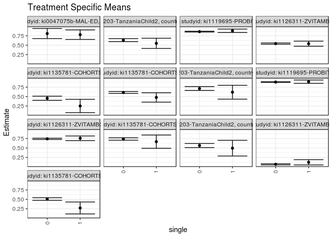

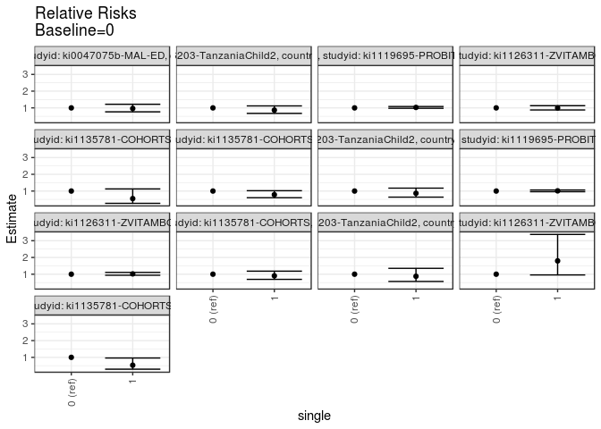

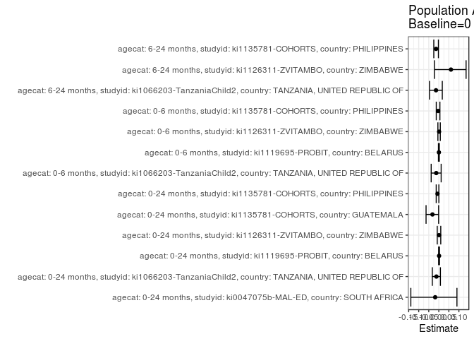

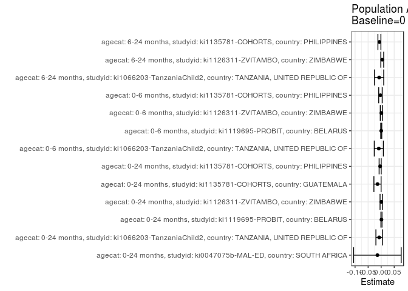

## Results Table

### Parameter: TSM

| agecat | studyid | country | intervention_level | baseline_level | estimate | ci_lower | ci_upper |
| --- | --- | --- | --- | --- | --- | --- | --- |
| 0-24 months | ki0047075b-MAL-ED | SOUTH AFRICA | 0 | NA | 0.8095238 | 0.6750720 | 0.9439757 |
| 0-24 months | ki0047075b-MAL-ED | SOUTH AFRICA | 1 | NA | 0.7804878 | 0.6540830 | 0.9068926 |
| 0-24 months | ki1066203-TanzaniaChild2 | TANZANIA, UNITED REPUBLIC OF | 0 | NA | 0.6342808 | 0.5948615 | 0.6737002 |
| 0-24 months | ki1066203-TanzaniaChild2 | TANZANIA, UNITED REPUBLIC OF | 1 | NA | 0.5496504 | 0.4140714 | 0.6852293 |
| 0-24 months | ki1119695-PROBIT | BELARUS | 0 | NA | 0.8600284 | 0.8496643 | 0.8703924 |
| 0-24 months | ki1119695-PROBIT | BELARUS | 1 | NA | 0.8838058 | 0.8386166 | 0.9289951 |
| 0-24 months | ki1126311-ZVITAMBO | ZIMBABWE | 0 | NA | 0.5430287 | 0.5259241 | 0.5601334 |
| 0-24 months | ki1126311-ZVITAMBO | ZIMBABWE | 1 | NA | 0.5402964 | 0.4733343 | 0.6072584 |
| 0-24 months | ki1135781-COHORTS | GUATEMALA | 0 | NA | 0.4559271 | 0.4002153 | 0.5116388 |
| 0-24 months | ki1135781-COHORTS | GUATEMALA | 1 | NA | 0.2500000 | 0.0728958 | 0.4271042 |
| 0-24 months | ki1135781-COHORTS | PHILIPPINES | 0 | NA | 0.6088659 | 0.5835903 | 0.6341415 |
| 0-24 months | ki1135781-COHORTS | PHILIPPINES | 1 | NA | 0.4769335 | 0.3524592 | 0.6014078 |
| 0-6 months | ki1066203-TanzaniaChild2 | TANZANIA, UNITED REPUBLIC OF | 0 | NA | 0.7131937 | 0.6615990 | 0.7647885 |
| 0-6 months | ki1066203-TanzaniaChild2 | TANZANIA, UNITED REPUBLIC OF | 1 | NA | 0.6167108 | 0.4331580 | 0.8002636 |
| 0-6 months | ki1119695-PROBIT | BELARUS | 0 | NA | 0.8851731 | 0.8753054 | 0.8950408 |
| 0-6 months | ki1119695-PROBIT | BELARUS | 1 | NA | 0.8952099 | 0.8508175 | 0.9396023 |
| 0-6 months | ki1126311-ZVITAMBO | ZIMBABWE | 0 | NA | 0.7422784 | 0.7246284 | 0.7599283 |
| 0-6 months | ki1126311-ZVITAMBO | ZIMBABWE | 1 | NA | 0.7561799 | 0.6949248 | 0.8174351 |
| 0-6 months | ki1135781-COHORTS | PHILIPPINES | 0 | NA | 0.7380282 | 0.7055710 | 0.7704853 |
| 0-6 months | ki1135781-COHORTS | PHILIPPINES | 1 | NA | 0.6666667 | 0.4900832 | 0.8432501 |
| 6-24 months | ki1066203-TanzaniaChild2 | TANZANIA, UNITED REPUBLIC OF | 0 | NA | 0.5642136 | 0.5097143 | 0.6187129 |
| 6-24 months | ki1066203-TanzaniaChild2 | TANZANIA, UNITED REPUBLIC OF | 1 | NA | 0.4941966 | 0.2856091 | 0.7027841 |
| 6-24 months | ki1126311-ZVITAMBO | ZIMBABWE | 0 | NA | 0.0659056 | 0.0503915 | 0.0814198 |
| 6-24 months | ki1126311-ZVITAMBO | ZIMBABWE | 1 | NA | 0.1183245 | 0.0490278 | 0.1876211 |
| 6-24 months | ki1135781-COHORTS | PHILIPPINES | 0 | NA | 0.5077951 | 0.4732557 | 0.5423345 |
| 6-24 months | ki1135781-COHORTS | PHILIPPINES | 1 | NA | 0.2692308 | 0.1105079 | 0.4279537 |

### Parameter: E(Y)

| agecat | studyid | country | intervention_level | baseline_level | estimate | ci_lower | ci_upper |
| --- | --- | --- | --- | --- | --- | --- | --- |
| 0-24 months | ki0047075b-MAL-ED | SOUTH AFRICA | NA | NA | 0.7951807 | 0.7027530 | 0.8876084 |
| 0-24 months | ki1066203-TanzaniaChild2 | TANZANIA, UNITED REPUBLIC OF | NA | NA | 0.6267606 | 0.5890263 | 0.6644948 |
| 0-24 months | ki1119695-PROBIT | BELARUS | NA | NA | 0.8612051 | 0.8511051 | 0.8713052 |
| 0-24 months | ki1126311-ZVITAMBO | ZIMBABWE | NA | NA | 0.5435883 | 0.5270723 | 0.5601043 |
| 0-24 months | ki1135781-COHORTS | GUATEMALA | NA | NA | 0.4419263 | 0.3882796 | 0.4955731 |
| 0-24 months | ki1135781-COHORTS | PHILIPPINES | NA | NA | 0.6050572 | 0.5803571 | 0.6297573 |
| 0-6 months | ki1066203-TanzaniaChild2 | TANZANIA, UNITED REPUBLIC OF | NA | NA | 0.7041420 | 0.6547600 | 0.7535240 |
| 0-6 months | ki1119695-PROBIT | BELARUS | NA | NA | 0.8855266 | 0.8758983 | 0.8951550 |
| 0-6 months | ki1126311-ZVITAMBO | ZIMBABWE | NA | NA | 0.7433027 | 0.7261944 | 0.7604109 |
| 0-6 months | ki1135781-COHORTS | PHILIPPINES | NA | NA | 0.7354138 | 0.7034648 | 0.7673628 |
| 6-24 months | ki1066203-TanzaniaChild2 | TANZANIA, UNITED REPUBLIC OF | NA | NA | 0.5564516 | 0.5041613 | 0.6087419 |
| 6-24 months | ki1126311-ZVITAMBO | ZIMBABWE | NA | NA | 0.0701422 | 0.0548634 | 0.0854209 |
| 6-24 months | ki1135781-COHORTS | PHILIPPINES | NA | NA | 0.5010823 | 0.4670433 | 0.5351212 |

### Parameter: RR

| agecat | studyid | country | intervention_level | baseline_level | estimate | ci_lower | ci_upper |
| --- | --- | --- | --- | --- | --- | --- | --- |
| 0-24 months | ki0047075b-MAL-ED | SOUTH AFRICA | 0 | 0 | 1.0000000 | 1.0000000 | 1.0000000 |
| 0-24 months | ki0047075b-MAL-ED | SOUTH AFRICA | 1 | 0 | 0.9641320 | 0.7645047 | 1.2158859 |
| 0-24 months | ki1066203-TanzaniaChild2 | TANZANIA, UNITED REPUBLIC OF | 0 | 0 | 1.0000000 | 1.0000000 | 1.0000000 |
| 0-24 months | ki1066203-TanzaniaChild2 | TANZANIA, UNITED REPUBLIC OF | 1 | 0 | 0.8665726 | 0.6719826 | 1.1175112 |
| 0-24 months | ki1119695-PROBIT | BELARUS | 0 | 0 | 1.0000000 | 1.0000000 | 1.0000000 |
| 0-24 months | ki1119695-PROBIT | BELARUS | 1 | 0 | 1.0276473 | 0.9750530 | 1.0830786 |
| 0-24 months | ki1126311-ZVITAMBO | ZIMBABWE | 0 | 0 | 1.0000000 | 1.0000000 | 1.0000000 |
| 0-24 months | ki1126311-ZVITAMBO | ZIMBABWE | 1 | 0 | 0.9949683 | 0.8757911 | 1.1303630 |
| 0-24 months | ki1135781-COHORTS | GUATEMALA | 0 | 0 | 1.0000000 | 1.0000000 | 1.0000000 |
| 0-24 months | ki1135781-COHORTS | GUATEMALA | 1 | 0 | 0.5483333 | 0.2671990 | 1.1252640 |
| 0-24 months | ki1135781-COHORTS | PHILIPPINES | 0 | 0 | 1.0000000 | 1.0000000 | 1.0000000 |
| 0-24 months | ki1135781-COHORTS | PHILIPPINES | 1 | 0 | 0.7833145 | 0.6014094 | 1.0202395 |
| 0-6 months | ki1066203-TanzaniaChild2 | TANZANIA, UNITED REPUBLIC OF | 0 | 0 | 1.0000000 | 1.0000000 | 1.0000000 |
| 0-6 months | ki1066203-TanzaniaChild2 | TANZANIA, UNITED REPUBLIC OF | 1 | 0 | 0.8647171 | 0.6364094 | 1.1749286 |
| 0-6 months | ki1119695-PROBIT | BELARUS | 0 | 0 | 1.0000000 | 1.0000000 | 1.0000000 |
| 0-6 months | ki1119695-PROBIT | BELARUS | 1 | 0 | 1.0113388 | 0.9612269 | 1.0640632 |
| 0-6 months | ki1126311-ZVITAMBO | ZIMBABWE | 0 | 0 | 1.0000000 | 1.0000000 | 1.0000000 |
| 0-6 months | ki1126311-ZVITAMBO | ZIMBABWE | 1 | 0 | 1.0187282 | 0.9371126 | 1.1074520 |
| 0-6 months | ki1135781-COHORTS | PHILIPPINES | 0 | 0 | 1.0000000 | 1.0000000 | 1.0000000 |
| 0-6 months | ki1135781-COHORTS | PHILIPPINES | 1 | 0 | 0.9033079 | 0.6906013 | 1.1815285 |
| 6-24 months | ki1066203-TanzaniaChild2 | TANZANIA, UNITED REPUBLIC OF | 0 | 0 | 1.0000000 | 1.0000000 | 1.0000000 |
| 6-24 months | ki1066203-TanzaniaChild2 | TANZANIA, UNITED REPUBLIC OF | 1 | 0 | 0.8759034 | 0.5680002 | 1.3507157 |
| 6-24 months | ki1126311-ZVITAMBO | ZIMBABWE | 0 | 0 | 1.0000000 | 1.0000000 | 1.0000000 |
| 6-24 months | ki1126311-ZVITAMBO | ZIMBABWE | 1 | 0 | 1.7953626 | 0.9547894 | 3.3759558 |
| 6-24 months | ki1135781-COHORTS | PHILIPPINES | 0 | 0 | 1.0000000 | 1.0000000 | 1.0000000 |
| 6-24 months | ki1135781-COHORTS | PHILIPPINES | 1 | 0 | 0.5301957 | 0.2928894 | 0.9597734 |

### Parameter: PAR

| agecat | studyid | country | intervention_level | baseline_level | estimate | ci_lower | ci_upper |
| --- | --- | --- | --- | --- | --- | --- | --- |
| 0-24 months | ki0047075b-MAL-ED | SOUTH AFRICA | 0 | NA | -0.0143431 | -0.1055140 | 0.0768278 |
| 0-24 months | ki1066203-TanzaniaChild2 | TANZANIA, UNITED REPUBLIC OF | 0 | NA | -0.0075203 | -0.0201240 | 0.0050834 |
| 0-24 months | ki1119695-PROBIT | BELARUS | 0 | NA | 0.0011768 | -0.0009077 | 0.0032612 |
| 0-24 months | ki1126311-ZVITAMBO | ZIMBABWE | 0 | NA | 0.0005596 | -0.0042097 | 0.0053288 |
| 0-24 months | ki1135781-COHORTS | GUATEMALA | 0 | NA | -0.0140007 | -0.0277753 | -0.0002261 |
| 0-24 months | ki1135781-COHORTS | PHILIPPINES | 0 | NA | -0.0038087 | -0.0078184 | 0.0002010 |
| 0-6 months | ki1066203-TanzaniaChild2 | TANZANIA, UNITED REPUBLIC OF | 0 | NA | -0.0090517 | -0.0264781 | 0.0083746 |
| 0-6 months | ki1119695-PROBIT | BELARUS | 0 | NA | 0.0003535 | -0.0017107 | 0.0024177 |
| 0-6 months | ki1126311-ZVITAMBO | ZIMBABWE | 0 | NA | 0.0010243 | -0.0034135 | 0.0054621 |
| 0-6 months | ki1135781-COHORTS | PHILIPPINES | 0 | NA | -0.0026143 | -0.0092776 | 0.0040489 |
| 6-24 months | ki1066203-TanzaniaChild2 | TANZANIA, UNITED REPUBLIC OF | 0 | NA | -0.0077620 | -0.0253855 | 0.0098616 |
| 6-24 months | ki1126311-ZVITAMBO | ZIMBABWE | 0 | NA | 0.0042366 | -0.0013260 | 0.0097992 |
| 6-24 months | ki1135781-COHORTS | PHILIPPINES | 0 | NA | -0.0067128 | -0.0124377 | -0.0009880 |

### Parameter: PAF

| agecat | studyid | country | intervention_level | baseline_level | estimate | ci_lower | ci_upper |
| --- | --- | --- | --- | --- | --- | --- | --- |
| 0-24 months | ki0047075b-MAL-ED | SOUTH AFRICA | 0 | NA | -0.0180375 | -0.1392487 | 0.0902773 |
| 0-24 months | ki1066203-TanzaniaChild2 | TANZANIA, UNITED REPUBLIC OF | 0 | NA | -0.0119987 | -0.0323446 | 0.0079463 |
| 0-24 months | ki1119695-PROBIT | BELARUS | 0 | NA | 0.0013664 | -0.0010573 | 0.0037843 |
| 0-24 months | ki1126311-ZVITAMBO | ZIMBABWE | 0 | NA | 0.0010294 | -0.0077824 | 0.0097641 |
| 0-24 months | ki1135781-COHORTS | GUATEMALA | 0 | NA | -0.0316811 | -0.0634737 | -0.0008389 |
| 0-24 months | ki1135781-COHORTS | PHILIPPINES | 0 | NA | -0.0062948 | -0.0129321 | 0.0002990 |
| 0-6 months | ki1066203-TanzaniaChild2 | TANZANIA, UNITED REPUBLIC OF | 0 | NA | -0.0128550 | -0.0379680 | 0.0116504 |
| 0-6 months | ki1119695-PROBIT | BELARUS | 0 | NA | 0.0003992 | -0.0019346 | 0.0027276 |
| 0-6 months | ki1126311-ZVITAMBO | ZIMBABWE | 0 | NA | 0.0013781 | -0.0046101 | 0.0073306 |
| 0-6 months | ki1135781-COHORTS | PHILIPPINES | 0 | NA | -0.0035549 | -0.0126621 | 0.0054704 |
| 6-24 months | ki1066203-TanzaniaChild2 | TANZANIA, UNITED REPUBLIC OF | 0 | NA | -0.0139491 | -0.0462029 | 0.0173104 |
| 6-24 months | ki1126311-ZVITAMBO | ZIMBABWE | 0 | NA | 0.0603997 | -0.0215362 | 0.1357636 |
| 6-24 months | ki1135781-COHORTS | PHILIPPINES | 0 | NA | -0.0133967 | -0.0249192 | -0.0020037 |